# Pokémon Market Analytics

## Integrating Pokémon Statistics, API Data, and Trading Card Market Prices Using Python, SQL, and SQLite

### Project Overview

This project integrates Pokémon game statistics, PokéAPI attributes, and trading card marketplace data into a unified analytical database. Data were collected from multiple sources, cleaned and standardized using Python and pandas, stored in SQLite, and integrated using SQL joins.

The resulting dataset was used to explore relationships between Pokémon characteristics, rarity classifications, and marketplace pricing behavior. Visualizations were developed to identify factors associated with higher card values and to demonstrate the use of multi-source data integration within a relational database environment.

### Project Objectives

- Clean and standardize Pokémon datasets from multiple sources
- Integrate flat-file, API, and marketplace data using SQLite
- Perform SQL joins to create a consolidated analytical dataset
- Explore factors associated with Pokémon card market values
- Demonstrate end-to-end data preparation and visualization workflows

### Technologies Used

- Python
- Pandas
- NumPy
- SQLite
- SQL
- Requests
- Matplotlib
- Seaborn
- PokéAPI

```python
import pandas as pd
import numpy as np

df = pd.read_csv("pokemon.csv")

df.head()
```

|  | # | Name | Type 1 | Type 2 | Total | HP | Attack | Defense | Sp. Atk | Sp. Def | Speed | Generation | Legendary |
| --- | --- | --- | --- | --- | --- | --- | --- | --- | --- | --- | --- | --- | --- |
| 0 | 1 | Bulbasaur | Grass | Poison | 318 | 45 | 49 | 49 | 65 | 65 | 45 | 1 | False |
| 1 | 2 | Ivysaur | Grass | Poison | 405 | 60 | 62 | 63 | 80 | 80 | 60 | 1 | False |
| 2 | 3 | Venusaur | Grass | Poison | 525 | 80 | 82 | 83 | 100 | 100 | 80 | 1 | False |
| 3 | 3 | VenusaurMega Venusaur | Grass | Poison | 625 | 80 | 100 | 123 | 122 | 120 | 80 | 1 | False |
| 4 | 4 | Charmander | Fire | NaN | 309 | 39 | 52 | 43 | 60 | 50 | 65 | 1 | False |

## Data Cleaning: Standardizing Column Names

```python
# Standardize column names
df.columns = (
    df.columns
    .str.strip()
    .str.lower()
    .str.replace(" ", "_")
    .str.replace(".", "", regex=False)
)

print(df.columns.tolist())
```

```
['#', 'name', 'type_1', 'type_2', 'total', 'hp', 'attack', 'defense', 'sp_atk', 'sp_def', 'speed', 'generation', 'legendary']
```

Column names were standardized by converting them to lowercase and replacing spaces with underscores. This improves consistency, readability, and ease of use when referencing variables in analysis.

## Data Cleaning: Handling Missing Pokémon Types

```python
# Fill missing Type 2 values
df["type_2"] = df["type_2"].fillna("None")
```

Missing values in the secondary type column were replaced with "None" to indicate that certain Pokémon have only one type. This ensures that missing data is handled explicitly rather than left ambiguous.

## Data Cleaning: Removing Duplicate Records

```python
# Remove duplicate rows
before = df.shape
df = df.drop_duplicates()
after = df.shape

print("Before:", before)
print("After:", after)
```

```
Before: (800, 13)
After: (800, 13)
```

## Data Cleaning: Fix Casing Issues

```python
# Standardize text casing
df["name"] = df["name"].str.title()
df["type_1"] = df["type_1"].str.title()
df["type_2"] = df["type_2"].str.title()
```

Text values were standardized using title case to ensure consistent formatting across categorical variables, improving readability and preventing mismatches during analysis.

## Data Cleaning: Identify and Remove Outliers

```python
# Remove extreme outliers in stats (example: HP > 250)
df = df[df["hp"] <= 250]
```

Extreme values in the HP column were removed to reduce the influence of outliers. These unusually high values may distort analysis and do not represent typical observations in the dataset.

## Data Cleaning: Create Calculated Total Stats Feature

### Cleaned Card Dataset

A new calculated total stats column was created by summing all base battle statistics (HP, Attack, Defense, Special Attack, Special Defense, and Speed). This provides a comprehensive metric for overall Pokémon strength and allows for validation of the existing total column. The dataset below reflects all transformations applied, resulting in a clean and structured dataset ready for analysis.

### Validation Step

The calculated total stats were compared to the original total column to ensure consistency. The results show that all values match, confirming that the transformation was performed correctly and that the dataset maintains data integrity.

```python
# Create a calculated total stats column
df["calculated_total_stats"] = df[[
    "hp", "attack", "defense", "sp_atk", "sp_def", "speed"
]].sum(axis=1)

df.head(20)
```

|  | # | name | type_1 | type_2 | total | hp | attack | defense | sp_atk | sp_def | speed | generation | legendary | calculated_total_stats |
| --- | --- | --- | --- | --- | --- | --- | --- | --- | --- | --- | --- | --- | --- | --- |
| 0 | 1 | Bulbasaur | Grass | Poison | 318 | 45 | 49 | 49 | 65 | 65 | 45 | 1 | False | 318 |
| 1 | 2 | Ivysaur | Grass | Poison | 405 | 60 | 62 | 63 | 80 | 80 | 60 | 1 | False | 405 |
| 2 | 3 | Venusaur | Grass | Poison | 525 | 80 | 82 | 83 | 100 | 100 | 80 | 1 | False | 525 |
| 3 | 3 | Venusaurmega Venusaur | Grass | Poison | 625 | 80 | 100 | 123 | 122 | 120 | 80 | 1 | False | 625 |
| 4 | 4 | Charmander | Fire | None | 309 | 39 | 52 | 43 | 60 | 50 | 65 | 1 | False | 309 |
| 5 | 5 | Charmeleon | Fire | None | 405 | 58 | 64 | 58 | 80 | 65 | 80 | 1 | False | 405 |
| 6 | 6 | Charizard | Fire | Flying | 534 | 78 | 84 | 78 | 109 | 85 | 100 | 1 | False | 534 |
| 7 | 6 | Charizardmega Charizard X | Fire | Dragon | 634 | 78 | 130 | 111 | 130 | 85 | 100 | 1 | False | 634 |
| 8 | 6 | Charizardmega Charizard Y | Fire | Flying | 634 | 78 | 104 | 78 | 159 | 115 | 100 | 1 | False | 634 |
| 9 | 7 | Squirtle | Water | None | 314 | 44 | 48 | 65 | 50 | 64 | 43 | 1 | False | 314 |
| 10 | 8 | Wartortle | Water | None | 405 | 59 | 63 | 80 | 65 | 80 | 58 | 1 | False | 405 |
| 11 | 9 | Blastoise | Water | None | 530 | 79 | 83 | 100 | 85 | 105 | 78 | 1 | False | 530 |
| 12 | 9 | Blastoisemega Blastoise | Water | None | 630 | 79 | 103 | 120 | 135 | 115 | 78 | 1 | False | 630 |
| 13 | 10 | Caterpie | Bug | None | 195 | 45 | 30 | 35 | 20 | 20 | 45 | 1 | False | 195 |
| 14 | 11 | Metapod | Bug | None | 205 | 50 | 20 | 55 | 25 | 25 | 30 | 1 | False | 205 |
| 15 | 12 | Butterfree | Bug | Flying | 395 | 60 | 45 | 50 | 90 | 80 | 70 | 1 | False | 395 |
| 16 | 13 | Weedle | Bug | Poison | 195 | 40 | 35 | 30 | 20 | 20 | 50 | 1 | False | 195 |
| 17 | 14 | Kakuna | Bug | Poison | 205 | 45 | 25 | 50 | 25 | 25 | 35 | 1 | False | 205 |
| 18 | 15 | Beedrill | Bug | Poison | 395 | 65 | 90 | 40 | 45 | 80 | 75 | 1 | False | 395 |
| 19 | 15 | Beedrillmega Beedrill | Bug | Poison | 495 | 65 | 150 | 40 | 15 | 80 | 145 | 1 | False | 495 |

```python
df["total_matches"] = df["total"] == df["calculated_total_stats"]

df["total_matches"].value_counts()
```

```
total_matches
True    799
Name: count, dtype: int64
```

### Ethical Considerations

Several transformations were applied to improve the quality and usability of the dataset, including handling missing values, removing duplicates, standardizing text formatting, and removing outliers. These changes were made to enhance consistency and ensure the dataset is suitable for analysis.

Since this dataset is based on publicly available Pokémon data, there are no direct legal or regulatory concerns associated with its use. However, assumptions were made during the cleaning process, such as replacing missing values in the "Type 2" column with "None" and defining thresholds for outlier removal. These assumptions may influence how the data is interpreted.

One potential risk is that removing outliers could eliminate valid but rare observations, potentially introducing bias into the dataset. Additionally, transformations such as standardizing categorical values may alter the original representation of the data if not carefully documented.

The dataset was sourced from a widely used public dataset intended for educational and analytical purposes, and it is considered credible. No personal or sensitive information is included, and the data was acquired ethically.

To mitigate ethical concerns, all transformations were clearly documented and justified. This ensures transparency and allows others to reproduce, evaluate, or modify the data preparation process as needed.

## Web Data Extraction and Cleaning

## Dataset Assessment

Initial inspection of the extracted Pokémon website data showed that the dataset was already relatively structured and well-maintained. Unlike highly unstructured web data, the dataset contained standardized numerical statistics, categorical Pokémon types, and minimal formatting inconsistencies.

Because the source data was largely consistent, the primary focus shifted toward data validation, formatting standardization, and integrity verification rather than extensive correction of missing or corrupted information. The transformations performed below were intended to confirm dataset reliability while improving readability and consistency for future analysis.

## Web Data Extraction and Preparation

The Pokémon statistics dataset was extracted directly from an HTML table using pandas `read_html()`. Acquiring the data directly from the webpage ensured that the analysis was based on current source information and demonstrated a web-based data acquisition workflow.

```python
# !pip install lxml html5lib beautifulsoup4
```

```python
import pandas as pd
import requests
from io import StringIO

# Website source containing Pokémon stat table
url = "https://pokemondb.net/pokedex/all"

# Request the webpage using a browser-like header
headers = {
    "User-Agent": "Mozilla/5.0"
}

response = requests.get(url, headers=headers)

# Check that the website request worked
print("Status code:", response.status_code)

# Read HTML tables from the webpage source
tables = pd.read_html(StringIO(response.text))

# Select the first table, which contains the Pokémon data
df = tables[0]

# Confirm extraction
print("Number of tables found:", len(tables))
print("Dataset shape:", df.shape)

df.head()
```

```
Status code: 200
Number of tables found: 1
Dataset shape: (1219, 10)
```

|  | # | Name | Type | Total | HP | Attack | Defense | Sp. Atk | Sp. Def | Speed |
| --- | --- | --- | --- | --- | --- | --- | --- | --- | --- | --- |
| 0 | 1 | Bulbasaur | Grass Poison | 318 | 45 | 49 | 49 | 65 | 65 | 45 |
| 1 | 2 | Ivysaur | Grass Poison | 405 | 60 | 62 | 63 | 80 | 80 | 60 |
| 2 | 3 | Venusaur | Grass Poison | 525 | 80 | 82 | 83 | 100 | 100 | 80 |
| 3 | 3 | Venusaur Mega Venusaur | Grass Poison | 625 | 80 | 100 | 123 | 122 | 120 | 80 |
| 4 | 4 | Charmander | Fire | 309 | 39 | 52 | 43 | 60 | 50 | 65 |

## Standardize Column Headers

Column names were cleaned and standardized to improve readability and consistency throughout the project.

```python
df.columns = (
    df.columns
    .str.strip()
    .str.lower()
    .str.replace(" ", "_")
    .str.replace(".", "", regex=False)
)

df.head()
```

|  | # | name | type | total | hp | attack | defense | sp_atk | sp_def | speed |
| --- | --- | --- | --- | --- | --- | --- | --- | --- | --- | --- |
| 0 | 1 | Bulbasaur | Grass Poison | 318 | 45 | 49 | 49 | 65 | 65 | 45 |
| 1 | 2 | Ivysaur | Grass Poison | 405 | 60 | 62 | 63 | 80 | 80 | 60 |
| 2 | 3 | Venusaur | Grass Poison | 525 | 80 | 82 | 83 | 100 | 100 | 80 |
| 3 | 3 | Venusaur Mega Venusaur | Grass Poison | 625 | 80 | 100 | 123 | 122 | 120 | 80 |
| 4 | 4 | Charmander | Fire | 309 | 39 | 52 | 43 | 60 | 50 | 65 |

## Standardize Text Formatting

Text values were standardized to title case to eliminate inconsistent capitalization and improve readability.

```python
# Standardize Pokémon names
df["name"] = df["name"].str.title()

# Standardize Pokémon types
# Standardize Pokémon names
df["name"] = df["name"].str.title()

# Standardize Pokémon type text
df["type"] = df["type"].str.title()

df.head()
```

|  | # | name | type | total | hp | attack | defense | sp_atk | sp_def | speed |
| --- | --- | --- | --- | --- | --- | --- | --- | --- | --- | --- |
| 0 | 1 | Bulbasaur | Grass Poison | 318 | 45 | 49 | 49 | 65 | 65 | 45 |
| 1 | 2 | Ivysaur | Grass Poison | 405 | 60 | 62 | 63 | 80 | 80 | 60 |
| 2 | 3 | Venusaur | Grass Poison | 525 | 80 | 82 | 83 | 100 | 100 | 80 |
| 3 | 3 | Venusaur Mega Venusaur | Grass Poison | 625 | 80 | 100 | 123 | 122 | 120 | 80 |
| 4 | 4 | Charmander | Fire | 309 | 39 | 52 | 43 | 60 | 50 | 65 |

Although the text values already appeared relatively consistent, this step ensures standardized formatting throughout the dataset and prevents future inconsistencies during analysis.

## Identify and Remove Duplicate Entries

Duplicate records were checked and removed to ensure that each Pokémon entry appeared only once in the dataset.

```python
# Check for duplicates
print("Duplicate rows before removal:", df.duplicated().sum())

# Remove duplicates
df = df.drop_duplicates()

# Verify duplicates removed
print("Duplicate rows after removal:", df.duplicated().sum())
```

```
Duplicate rows before removal: 0
Duplicate rows after removal: 0
```

No duplicate rows were identified in the dataset. This validation step confirmed that the dataset already contained unique Pokémon entries and did not require duplicate removal. Special Pokémon forms such as Mega Evolutions were intentionally retained because they represent legitimate variations within the original source data rather than duplicate records.

## Handle Missing Data

Missing values were identified and reviewed to improve dataset completeness and consistency before analysis.

```python
# Check missing values
missing_values = df.isnull().sum()

print(missing_values)
```

```
#          0
name       0
type       0
total      0
hp         0
attack     0
defense    0
sp_atk     0
sp_def     0
speed      0
dtype: int64
```

No missing values were identified in the dataset. This step confirmed that the extracted website data was already relatively complete and consistent.

## Validate Calculated Total Statistics

Calculated total statistics were compared against the reported total values to verify dataset consistency and identify potential data quality issues. The inclusion of the engineered validation columns (`calculated_total_stats` and `total_matches`) provided an additional mechanism for confirming data integrity and identifying potential inconsistencies within the scraped website data.

```python
print(df.columns)
```

```
Index(['#', 'name', 'type', 'total', 'hp', 'attack', 'defense', 'sp_atk',
       'sp_def', 'speed'],
      dtype='str')
```

```python
# Recalculate total stats from individual stat columns
df["calculated_total_stats"] = (
    df["hp"] +
    df["attack"] +
    df["defense"] +
    df["sp_atk"] +
    df["sp_def"] +
    df["speed"]
)

# Check whether calculated total matches reported total
df["total_matches"] = df["calculated_total_stats"] == df["total"]
```

```python
# Check whether calculated stats match reported totals
print(df["total_matches"].value_counts())

# Display rows where totals do not match
mismatched = df[df["total_matches"] == False]

print(mismatched)
```

```
total_matches
True    1219
Name: count, dtype: int64
Empty DataFrame
Columns: [#, name, type, total, hp, attack, defense, sp_atk, sp_def, speed, calculated_total_stats, total_matches]
Index: []
```

All calculated total statistics matched the reported total values in the dataset. This validation step confirmed the consistency and integrity of the extracted Pokémon stat information.

# Final Cleaned Dataset

```python
df.head(20)
```

|  | # | name | type | total | hp | attack | defense | sp_atk | sp_def | speed | calculated_total_stats | total_matches |
| --- | --- | --- | --- | --- | --- | --- | --- | --- | --- | --- | --- | --- |
| 0 | 1 | Bulbasaur | Grass Poison | 318 | 45 | 49 | 49 | 65 | 65 | 45 | 318 | True |
| 1 | 2 | Ivysaur | Grass Poison | 405 | 60 | 62 | 63 | 80 | 80 | 60 | 405 | True |
| 2 | 3 | Venusaur | Grass Poison | 525 | 80 | 82 | 83 | 100 | 100 | 80 | 525 | True |
| 3 | 3 | Venusaur Mega Venusaur | Grass Poison | 625 | 80 | 100 | 123 | 122 | 120 | 80 | 625 | True |
| 4 | 4 | Charmander | Fire | 309 | 39 | 52 | 43 | 60 | 50 | 65 | 309 | True |
| 5 | 5 | Charmeleon | Fire | 405 | 58 | 64 | 58 | 80 | 65 | 80 | 405 | True |
| 6 | 6 | Charizard | Fire Flying | 534 | 78 | 84 | 78 | 109 | 85 | 100 | 534 | True |
| 7 | 6 | Charizard Mega Charizard X | Fire Dragon | 634 | 78 | 130 | 111 | 130 | 85 | 100 | 634 | True |
| 8 | 6 | Charizard Mega Charizard Y | Fire Flying | 634 | 78 | 104 | 78 | 159 | 115 | 100 | 634 | True |
| 9 | 7 | Squirtle | Water | 314 | 44 | 48 | 65 | 50 | 64 | 43 | 314 | True |
| 10 | 8 | Wartortle | Water | 405 | 59 | 63 | 80 | 65 | 80 | 58 | 405 | True |
| 11 | 9 | Blastoise | Water | 530 | 79 | 83 | 100 | 85 | 105 | 78 | 530 | True |
| 12 | 9 | Blastoise Mega Blastoise | Water | 630 | 79 | 103 | 120 | 135 | 115 | 78 | 630 | True |
| 13 | 10 | Caterpie | Bug | 195 | 45 | 30 | 35 | 20 | 20 | 45 | 195 | True |
| 14 | 11 | Metapod | Bug | 205 | 50 | 20 | 55 | 25 | 25 | 30 | 205 | True |
| 15 | 12 | Butterfree | Bug Flying | 395 | 60 | 45 | 50 | 90 | 80 | 70 | 395 | True |
| 16 | 13 | Weedle | Bug Poison | 195 | 40 | 35 | 30 | 20 | 20 | 50 | 195 | True |
| 17 | 14 | Kakuna | Bug Poison | 205 | 45 | 25 | 50 | 25 | 25 | 35 | 205 | True |
| 18 | 15 | Beedrill | Bug Poison | 395 | 65 | 90 | 40 | 45 | 80 | 75 | 395 | True |
| 19 | 15 | Beedrill Mega Beedrill | Bug Poison | 495 | 65 | 150 | 40 | 15 | 80 | 145 | 495 | True |

## Ethical Implications

The Pokémon dataset used in this project does not contain sensitive personal information and is intended primarily for entertainment and educational purposes. The data was sourced from a publicly accessible Pokémon website maintained by dedicated community contributors and fans. Because the information is publicly available and widely referenced within the Pokémon community, it was considered an appropriate and credible source for this project.

Several data cleaning and formatting transformations were performed, including standardizing headers, validating duplicate records, checking for missing values, and verifying calculated statistics against reported totals. These transformations were intended to improve consistency, readability, and overall data quality without altering the meaning of the original information.

Although this dataset is low risk compared to datasets involving personal or medical information, ethical considerations still apply during data wrangling. Improper transformations or assumptions could unintentionally misrepresent the original data. For example, incorrectly removing valid records or modifying statistical values could distort Pokémon attributes and affect future analysis. To mitigate these risks, all transformations were documented clearly, and validation steps were performed to preserve the integrity and accuracy of the dataset.

## API Data Integration

### Objective

Pokémon attribute data were retrieved directly from the PokéAPI in JSON format and transformed into a structured analytical dataset. Several cleaning and standardization steps were performed to improve readability, consistency, and compatibility with the relational database used later in the project.

## API Data Source

Pokémon data was pulled directly from the PokéAPI JSON source using the `requests` library. The API response was converted into a pandas DataFrame so the data could be cleaned, formatted, and validated without exporting it to a CSV file.

```python
import requests
import pandas as pd

# Pull Pokémon data directly from the API
url = "https://pokeapi.co/api/v2/pokemon?limit=150"

response = requests.get(url)

# Check that the API request worked
print("Status code:", response.status_code)

# Convert JSON response to Python dictionary
data = response.json()

# Extract Pokémon list from JSON response
pokemon_list = data["results"]

# Convert API results into a DataFrame
df_api = pd.DataFrame(pokemon_list)

print("Dataset shape:", df_api.shape)

df_api.head()
```

```
Status code: 200
Dataset shape: (150, 2)
```

|  | name | url |
| --- | --- | --- |
| 0 | bulbasaur | https://pokeapi.co/api/v2/pokemon/1/ |
| 1 | ivysaur | https://pokeapi.co/api/v2/pokemon/2/ |
| 2 | venusaur | https://pokeapi.co/api/v2/pokemon/3/ |
| 3 | charmander | https://pokeapi.co/api/v2/pokemon/4/ |
| 4 | charmeleon | https://pokeapi.co/api/v2/pokemon/5/ |

## Normalize API JSON Data

The API response was retrieved in JSON format and converted into a pandas DataFrame. This transformed the nested JSON response into a structured format that is easier to inspect and clean.

```python
# Inspect normalized API dataset
df_api.info()
```

```
<class 'pandas.DataFrame'>
RangeIndex: 150 entries, 0 to 149
Data columns (total 2 columns):
 #   Column  Non-Null Count  Dtype
---  ------  --------------  -----
 0   name    150 non-null    str
 1   url     150 non-null    str
dtypes: str(2)
memory usage: 2.5 KB
```

## Standardize Column Headers

```python
df_api.columns = (
    df_api.columns
    .str.strip()
    .str.lower()
    .str.replace(" ", "_")
)

print(df_api.columns)
```

```
Index(['name', 'url'], dtype='str')
```

## Standardize Pokémon Name Formatting

Pokémon names were converted to title case to improve readability and create consistent text formatting.

```python
df_api["name"] = df_api["name"].str.title()

df_api.head()
```

|  | name | url |
| --- | --- | --- |
| 0 | Bulbasaur | https://pokeapi.co/api/v2/pokemon/1/ |
| 1 | Ivysaur | https://pokeapi.co/api/v2/pokemon/2/ |
| 2 | Venusaur | https://pokeapi.co/api/v2/pokemon/3/ |
| 3 | Charmander | https://pokeapi.co/api/v2/pokemon/4/ |
| 4 | Charmeleon | https://pokeapi.co/api/v2/pokemon/5/ |

## Extract Pokémon ID from API URL

The Pokémon ID was extracted from the API URL using regular expressions to create a usable numeric identifier for each Pokémon record.

```python
df_api["pokemon_id"] = df_api["url"].str.extract(r"/pokemon/(\d+)/").astype(int)

df_api.head()
```

|  | name | url | pokemon_id |
| --- | --- | --- | --- |
| 0 | Bulbasaur | https://pokeapi.co/api/v2/pokemon/1/ | 1 |
| 1 | Ivysaur | https://pokeapi.co/api/v2/pokemon/2/ | 2 |
| 2 | Venusaur | https://pokeapi.co/api/v2/pokemon/3/ | 3 |
| 3 | Charmander | https://pokeapi.co/api/v2/pokemon/4/ | 4 |
| 4 | Charmeleon | https://pokeapi.co/api/v2/pokemon/5/ | 5 |

## Extract Additional Pokémon Attributes

Additional Pokémon attributes were retrieved from each Pokémon-specific API endpoint to create a richer dataset for cleaning and analysis.

```python
detailed_pokemon = []

for url in df_api["url"][:25]:
    pokemon_response = requests.get(url)
    pokemon_data = pokemon_response.json()

    detailed_pokemon.append({
        "name": pokemon_data["name"].title(),
        "height": pokemon_data["height"],
        "weight": pokemon_data["weight"],
        "base_experience": pokemon_data["base_experience"],
        "primary_type": pokemon_data["types"][0]["type"]["name"].title()
    })

detailed_df = pd.DataFrame(detailed_pokemon)

detailed_df.head()
```

|  | name | height | weight | base_experience | primary_type |
| --- | --- | --- | --- | --- | --- |
| 0 | Bulbasaur | 7 | 69 | 64 | Grass |
| 1 | Ivysaur | 10 | 130 | 142 | Grass |
| 2 | Venusaur | 20 | 1000 | 236 | Grass |
| 3 | Charmander | 6 | 85 | 62 | Fire |
| 4 | Charmeleon | 11 | 190 | 142 | Fire |

## Convert Height Units

Pokémon height values were converted from decimeters to meters to make the measurements easier to interpret.

```python
detailed_df["height_m"] = detailed_df["height"] / 10

# Rename raw API measurement columns
detailed_df = detailed_df.rename(columns={
    "height": "height_dm",
    "weight": "weight_hg"
})

detailed_df.head()
```

|  | name | height_dm | weight_hg | base_experience | primary_type | height_m |
| --- | --- | --- | --- | --- | --- | --- |
| 0 | Bulbasaur | 7 | 69 | 64 | Grass | 0.7 |
| 1 | Ivysaur | 10 | 130 | 142 | Grass | 1.0 |
| 2 | Venusaur | 20 | 1000 | 236 | Grass | 2.0 |
| 3 | Charmander | 6 | 85 | 62 | Fire | 0.6 |
| 4 | Charmeleon | 11 | 190 | 142 | Fire | 1.1 |

## Convert Weight Units

Pokémon weight values were converted from hectograms to kilograms to improve readability and standardize units for analysis.

```python
# Convert weight from hectograms to kilograms
detailed_df["weight_kg"] = detailed_df["weight_hg"] / 10

detailed_df.head()
```

|  | name | height_dm | weight_hg | base_experience | primary_type | height_m | weight_kg |
| --- | --- | --- | --- | --- | --- | --- | --- |
| 0 | Bulbasaur | 7 | 69 | 64 | Grass | 0.7 | 6.9 |
| 1 | Ivysaur | 10 | 130 | 142 | Grass | 1.0 | 13.0 |
| 2 | Venusaur | 20 | 1000 | 236 | Grass | 2.0 | 100.0 |
| 3 | Charmander | 6 | 85 | 62 | Fire | 0.6 | 8.5 |
| 4 | Charmeleon | 11 | 190 | 142 | Fire | 1.1 | 19.0 |

The original API weight values were preserved as `weight_hg`, while the converted `weight_kg` column provides a more interpretable measurement for analysis.

## Check for Missing Values

Missing values were checked to evaluate whether the API response contained incomplete records.

```python
# Check for missing values in the detailed API dataset
missing_values = detailed_df.isnull().sum()

print(missing_values)

# Display rows containing missing values (if any exist)
missing_rows = detailed_df[detailed_df.isnull().any(axis=1)]

print(missing_rows)
```

```
name               0
height_dm          0
weight_hg          0
base_experience    0
primary_type       0
height_m           0
weight_kg          0
dtype: int64
Empty DataFrame
Columns: [name, height_dm, weight_hg, base_experience, primary_type, height_m, weight_kg]
Index: []
```

No missing values were identified in the API dataset. This confirmed that the extracted records were complete for the selected fields.

## Check for Duplicate Records

Duplicate records were checked to ensure that each Pokémon entry appeared only once in the API dataset.

```python
# Check for duplicate records in the detailed API dataset
print("Duplicate rows:", detailed_df.duplicated().sum())

# Check for duplicate Pokémon names
print("Duplicate Pokémon names:", detailed_df["name"].duplicated().sum())
```

```
Duplicate rows: 0
Duplicate Pokémon names: 0
```

No duplicate records or duplicate Pokémon names were identified in the detailed API dataset. This confirmed that each extracted Pokémon entry represented a unique record.

## Final Cleaned API Dataset

The final cleaned API dataset is shown below after all formatting, extraction, and validation steps were completed.

```python
detailed_df.head(20)
```

|  | name | height_dm | weight_hg | base_experience | primary_type | height_m | weight_kg |
| --- | --- | --- | --- | --- | --- | --- | --- |
| 0 | Bulbasaur | 7 | 69 | 64 | Grass | 0.7 | 6.9 |
| 1 | Ivysaur | 10 | 130 | 142 | Grass | 1.0 | 13.0 |
| 2 | Venusaur | 20 | 1000 | 236 | Grass | 2.0 | 100.0 |
| 3 | Charmander | 6 | 85 | 62 | Fire | 0.6 | 8.5 |
| 4 | Charmeleon | 11 | 190 | 142 | Fire | 1.1 | 19.0 |
| 5 | Charizard | 17 | 905 | 240 | Fire | 1.7 | 90.5 |
| 6 | Squirtle | 5 | 90 | 63 | Water | 0.5 | 9.0 |
| 7 | Wartortle | 10 | 225 | 142 | Water | 1.0 | 22.5 |
| 8 | Blastoise | 16 | 855 | 239 | Water | 1.6 | 85.5 |
| 9 | Caterpie | 3 | 29 | 39 | Bug | 0.3 | 2.9 |
| 10 | Metapod | 7 | 99 | 72 | Bug | 0.7 | 9.9 |
| 11 | Butterfree | 11 | 320 | 178 | Bug | 1.1 | 32.0 |
| 12 | Weedle | 3 | 32 | 39 | Bug | 0.3 | 3.2 |
| 13 | Kakuna | 6 | 100 | 72 | Bug | 0.6 | 10.0 |
| 14 | Beedrill | 10 | 295 | 178 | Bug | 1.0 | 29.5 |
| 15 | Pidgey | 3 | 18 | 50 | Normal | 0.3 | 1.8 |
| 16 | Pidgeotto | 11 | 300 | 122 | Normal | 1.1 | 30.0 |
| 17 | Pidgeot | 15 | 395 | 216 | Normal | 1.5 | 39.5 |
| 18 | Rattata | 3 | 35 | 51 | Normal | 0.3 | 3.5 |
| 19 | Raticate | 7 | 185 | 145 | Normal | 0.7 | 18.5 |

## Ethical Implications

The Pokémon API data used in this project do not contain sensitive personal information and was collected from a publicly available API source. The transformations performed included normalizing JSON data into a DataFrame, standardizing column headers, formatting Pokémon names, extracting Pokémon IDs from URLs, and checking for missing or duplicate records. These changes were made to improve readability, consistency, and usability without altering the meaning of the original data. Although this dataset is low risk compared to data involving people, ethical considerations still apply. Incorrect transformations, such as extracting the wrong ID or mislabeling Pokémon names, could misrepresent the source data and affect future analysis. The data was sourced directly from the API rather than manually copied or exported, which supports transparency and reproducibility. To reduce ethical risks, all cleaning steps were documented clearly, and validation checks were used to confirm that the transformed dataset remained consistent with the original API source.

# Merging Data, Storing in SQLite, and Visualizing Results

## Objective

This section combines multiple cleaned Pokémon datasets into a SQLite database, joins the tables using SQL, and creates visualizations to analyze Pokémon statistics, API attributes, and trading card market pricing data.

```python
import pandas as pd
import sqlite3
import matplotlib.pyplot as plt
import seaborn as sns
```

## Load Cleaned Datasets

The cleaned Pokémon datasets were loaded into pandas DataFrames prior to database integration and visualization.

```python
# Create working copy of cleaned Pokémon statistics dataset
website_df = df.copy()

# Create working copy of cleaned PokéAPI dataset
api_df = detailed_df.copy()

# Load Pokémon card marketplace dataset
cards_df = pd.read_csv("pokemon_cards_ultimate_2026.csv")

print("Website dataset shape:", website_df.shape)
print("API dataset shape:", api_df.shape)
print("Card dataset shape:", cards_df.shape)
```

```
Website dataset shape: (1219, 12)
API dataset shape: (25, 7)
Card dataset shape: (542, 32)
```

## Inspect Pokémon Card Dataset

The Pokémon card pricing dataset was inspected to evaluate available variables, pricing fields, categorical attributes, and potential join keys.

```python
cards_df.head()
```

|  | title | pokemon_name | set_name | card_number | rarity_class | language | category | condition_std | is_graded | grading_company | ... | currency | price_usd | price_tier_usd | seller_country | seller_listing_count | ships_worldwide | image_count | days_since_sold | sale_month | sale_year |
| --- | --- | --- | --- | --- | --- | --- | --- | --- | --- | --- | --- | --- | --- | --- | --- | --- | --- | --- | --- | --- | --- |
| 0 | Ceruledge ex SAR 203/187 SV8a Terastal Fest ex... | Ceruledge | SV8A | 203/187 | SAR | Japanese | Single Cards | Near Mint | 0 | NaN | ... | GBP | 20.99 | Uncommon | United Kingdom | 15 | 0 | 2 | 2.0 | 5.0 | 2026.0 |
| 1 | Zacian V Holo SAR 225/172 S12a VSTAR Universe ... | Zacian | S12A | 225/172 | SAR | Japanese | Single Cards | Near Mint | 0 | NaN | ... | GBP | 15.17 | Uncommon | United Kingdom | 15 | 0 | 2 | 2.0 | 5.0 | 2026.0 |
| 2 | Piplup AR 085/080 M2 Japanese Pokemon Card Jap... | Piplup | INFERNO X | 085/080 | AR | Japanese | Single Cards | Near Mint | 0 | NaN | ... | GBP | 3.96 | Common | United Kingdom | 15 | 0 | 2 | 2.0 | 5.0 | 2026.0 |
| 3 | POKEMON Card Kyurem EX 25/98 XY Ancient Origin... | Kyurem | XY | 25/98 | Unknown | English | Single Cards | Near Mint | 0 | NaN | ... | GBP | 3.12 | Common | United Kingdom | 15 | 0 | 2 | 2.0 | 5.0 | 2026.0 |
| 4 | Pokemon Card Vulpix AR 067/063 M1L Mega Brave ... | Vulpix | MEGA BRAVE | 067/063 | AR | Japanese | Single Cards | Near Mint | 0 | NaN | ... | GBP | 2.71 | Common | United Kingdom | 15 | 0 | 2 | 2.0 | 5.0 | 2026.0 |

5 rows × 32 columns

```python
cards_df.info()
```

```
<class 'pandas.DataFrame'>
RangeIndex: 542 entries, 0 to 541
Data columns (total 32 columns):
 #   Column                Non-Null Count  Dtype
---  ------                --------------  -----
 0   title                 542 non-null    str
 1   pokemon_name          542 non-null    str
 2   set_name              542 non-null    str
 3   card_number           411 non-null    str
 4   rarity_class          542 non-null    str
 5   language              542 non-null    str
 6   category              542 non-null    str
 7   condition_std         542 non-null    str
 8   is_graded             542 non-null    int64
 9   grading_company       39 non-null     str
```

[output cut: 24 more lines]

## Standardize Card Dataset Headers

Column names were standardized to lowercase formatting with underscores to improve readability and consistency during SQL integration.

```python
cards_df.columns = (
    cards_df.columns
        .str.strip()
        .str.lower()
        .str.replace(" ", "_")
)

print(cards_df.columns)
```

```
Index(['title', 'pokemon_name', 'set_name', 'card_number', 'rarity_class',
       'language', 'category', 'condition_std', 'is_graded', 'grading_company',
       'numeric_grade', 'is_holo', 'is_full_art', 'is_v_card', 'is_ex_card',
       'is_gx_card', 'is_promo', 'is_shadowless', 'is_1st_edition',
       'is_rainbow', 'is_gold', 'price', 'currency', 'price_usd',
       'price_tier_usd', 'seller_country', 'seller_listing_count',
       'ships_worldwide', 'image_count', 'days_since_sold', 'sale_month',
       'sale_year'],
      dtype='str')
```

## Standardize Pokémon Name Formatting

Pokémon names were converted to title case to ensure consistency between datasets prior to SQL joins.

```python
cards_df["pokemon_name"] = cards_df["pokemon_name"].str.title()

cards_df[["pokemon_name"]].head()
```

|  | pokemon_name |
| --- | --- |
| 0 | Ceruledge |
| 1 | Zacian |
| 2 | Piplup |
| 3 | Kyurem |
| 4 | Vulpix |

## Handle Missing Numeric Grades

Missing grading values were replaced with 0 because ungraded cards do not contain numeric grading information.

```python
cards_df["numeric_grade"] = cards_df["numeric_grade"].fillna(0)

cards_df["numeric_grade"].head()
```

```
0    0.0
1    0.0
2    0.0
3    0.0
4    0.0
Name: numeric_grade, dtype: float64
```

## Remove Duplicate Card Listings

Duplicate records were removed to reduce redundant marketplace listings.

```python
print("Duplicate rows before cleaning:", cards_df.duplicated().sum())

cards_df = cards_df.drop_duplicates()

print("Duplicate rows after cleaning:", cards_df.duplicated().sum())
```

```
Duplicate rows before cleaning: 1
Duplicate rows after cleaning: 0
```

## Create Cleaned Card Dataset

A cleaned subset of important variables was created for SQL storage and exploratory analysis.

```python
cards_clean = cards_df[
    [
        "pokemon_name",
        "set_name",
        "rarity_class",
        "condition_std",
        "is_graded",
        "numeric_grade",
        "price_usd",
        "seller_country",
        "sale_year"
    ]
]

cards_clean.head()
```

|  | pokemon_name | set_name | rarity_class | condition_std | is_graded | numeric_grade | price_usd | seller_country | sale_year |
| --- | --- | --- | --- | --- | --- | --- | --- | --- | --- |
| 0 | Ceruledge | SV8A | SAR | Near Mint | 0 | 0.0 | 20.99 | United Kingdom | 2026.0 |
| 1 | Zacian | S12A | SAR | Near Mint | 0 | 0.0 | 15.17 | United Kingdom | 2026.0 |
| 2 | Piplup | INFERNO X | AR | Near Mint | 0 | 0.0 | 3.96 | United Kingdom | 2026.0 |
| 3 | Kyurem | XY | Unknown | Near Mint | 0 | 0.0 | 3.12 | United Kingdom | 2026.0 |
| 4 | Vulpix | MEGA BRAVE | AR | Near Mint | 0 | 0.0 | 2.71 | United Kingdom | 2026.0 |

## Database Construction

After cleaning and standardizing each dataset, the data were loaded into SQLite as independent relational tables. SQLite was selected because it provides a lightweight relational database system that supports SQL-based data integration and analysis.

Three tables were created:

- pokemon_website
- pokemon_api
- pokemon_cards

These tables were subsequently joined using SQL to create a consolidated analytical dataset.

## Create SQLite Database Connection

A SQLite database connection was created to store each cleaned dataset as an individual SQL table.

```python
conn = sqlite3.connect("pokemon_project.db")
```

```python
website_df = website_df.rename(columns={"type": "pokemon_type"})
```

## Store Cleaned Datasets as SQLite Tables

Each cleaned dataset was stored as an individual table within the SQLite database.

```python
website_df.to_sql(
    "pokemon_website",
    conn,
    if_exists="replace",
    index=False
)

api_df.to_sql(
    "pokemon_api",
    conn,
    if_exists="replace",
    index=False
)

cards_clean.to_sql(
    "pokemon_cards",
    conn,
    if_exists="replace",
    index=False
)
```

```
541
```

```python
# Verify tables were created

cursor = conn.cursor()

cursor.execute("""
SELECT name
FROM sqlite_master
WHERE type='table';
""")

print(cursor.fetchall())
```

```
[('pokemon_website',), ('pokemon_api',), ('pokemon_cards',)]
```

The output confirms that all three cleaned Pokémon datasets were successfully stored as individual tables within the SQLite database and are available for SQL-based integration and analysis.

## SQL Data Integration

The three Pokémon datasets were integrated using SQL INNER JOIN operations on standardized Pokémon name fields. This approach preserved relationships between game statistics, API-derived attributes, and trading card marketplace information while enabling analysis across multiple independent data sources.

The resulting merged dataset combined battle statistics, Pokémon attributes, rarity classifications, card conditions, and marketplace pricing information into a unified analytical view that served as the foundation for all subsequent visualizations and exploratory analysis.

### Join Strategy

An INNER JOIN was used to combine the three datasets based on Pokémon name fields. This ensured that only Pokémon present across all sources were included in the final analytical dataset. The join preserved relationships between game statistics, API attributes, and card marketplace information while maintaining data consistency.

### SQL Query

```python
query = """
SELECT
    w.name,
    w.pokemon_type,
    w.total,
    a.height_m,
    a.weight_kg,
    a.base_experience,
    c.rarity_class,
    c.price_usd,
    c.condition_std
FROM pokemon_website w
INNER JOIN pokemon_api a
    ON w.name = a.name
INNER JOIN pokemon_cards c
    ON w.name = c.pokemon_name;
"""

merged_df = pd.read_sql_query(query, conn)

merged_df.head()
```

|  | name | pokemon_type | total | height_m | weight_kg | base_experience | rarity_class | price_usd | condition_std |
| --- | --- | --- | --- | --- | --- | --- | --- | --- | --- |
| 0 | Bulbasaur | Grass Poison | 318 | 0.7 | 6.9 | 64 | Common | 17.09 | Near Mint |
| 1 | Bulbasaur | Grass Poison | 318 | 0.7 | 6.9 | 64 | Unknown | 27.93 | Near Mint |
| 2 | Ivysaur | Grass Poison | 405 | 1.0 | 13.0 | 142 | AR | 62.57 | ACE 10 |
| 3 | Ivysaur | Grass Poison | 405 | 1.0 | 13.0 | 142 | AR | 5.50 | Near Mint |
| 4 | Ivysaur | Grass Poison | 405 | 1.0 | 13.0 | 142 | Unknown | 42.31 | ACE 9 |

### Merged Dataset Preview

The merged analytical dataset contains variables originating from all three source systems, demonstrating successful relational integration within SQLite. The resulting dataset enables direct comparison of Pokémon characteristics, rarity classifications, and marketplace pricing behavior.

### Interpretation

The SQL joins successfully combined Pokémon statistics, API attributes, and trading card pricing information into a consolidated dataset. The merged dataset allows exploratory analysis between Pokémon characteristics, rarity classifications, and marketplace pricing behavior.

# Average Card Price by Pokémon Type

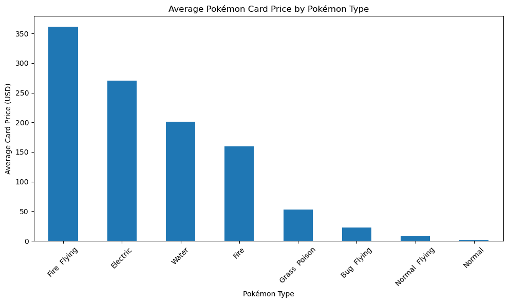

```python
avg_price_type = (
    merged_df.groupby("pokemon_type")["price_usd"]
    .mean()
    .sort_values(ascending=False)
)

plt.figure(figsize=(10,6))

avg_price_type.plot(kind="bar")

plt.title("Average Pokémon Card Price by Pokémon Type")
plt.xlabel("Pokémon Type")
plt.ylabel("Average Card Price (USD)")
plt.xticks(rotation=45)

plt.tight_layout()

plt.savefig(
    "avg_price_by_type.png",
    dpi=300,
    bbox_inches="tight"
)

plt.show()
```

### Key Findings

- Fire and Electric type Pokémon exhibited some of the highest average card prices.
- Normal and Bug type Pokémon generally showed lower average market values.
- These differences suggest that collector demand and rarity may influence card pricing beyond battle performance alone.

# Total Stats vs Card Price

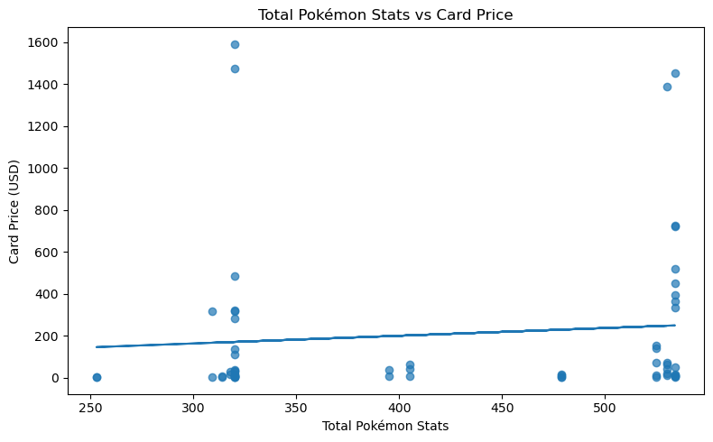

```python
import numpy as np
import matplotlib.pyplot as plt

plt.figure(figsize=(8, 5))

# Scatterplot using merged SQL dataset
plt.scatter(
    merged_df["total"],
    merged_df["price_usd"],
    alpha=0.7
)

# Regression line
m, b = np.polyfit(
    merged_df["total"],
    merged_df["price_usd"],
    1
)

plt.plot(
    merged_df["total"],
    m * merged_df["total"] + b
)

plt.xlabel("Total Pokémon Stats")
plt.ylabel("Card Price (USD)")
plt.title("Total Pokémon Stats vs Card Price")

plt.tight_layout()

plt.savefig(
    "stats_vs_price.png",
    dpi=300,
    bbox_inches="tight"
)

plt.show()
```

### Key Findings

- A weak positive relationship was observed between total Pokémon battle statistics and card price.
- While stronger Pokémon occasionally corresponded to higher card values, considerable variability remained.
- This suggests that rarity, condition, grading status, and collector demand likely have a greater influence on market pricing than battle statistics alone.

# Average Price by Rarity Class

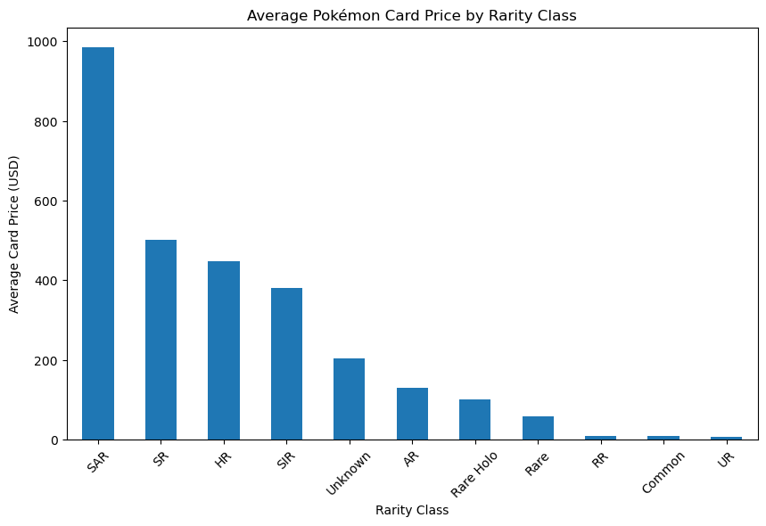

```python
avg_rarity_price = (
    merged_df.groupby("rarity_class")["price_usd"]
    .mean()
    .sort_values(ascending=False)
)

plt.figure(figsize=(10,6))

avg_rarity_price.plot(kind="bar")

plt.title("Average Pokémon Card Price by Rarity Class")
plt.xlabel("Rarity Class")
plt.ylabel("Average Card Price (USD)")
plt.xticks(rotation=45)

plt.show()
```

# Graded vs Ungraded Card Prices

[figure not shown]

```python
plt.figure(figsize=(8,6))

sns.boxplot(
    data=merged_df,
    x="condition_std",
    y="price_usd"
)

plt.title("Card Price Distribution by Card Condition")
plt.xlabel("Card Condition")
plt.ylabel("Card Price (USD)")
plt.xticks(rotation=45)

plt.show()
```

# Seller Country Distribution

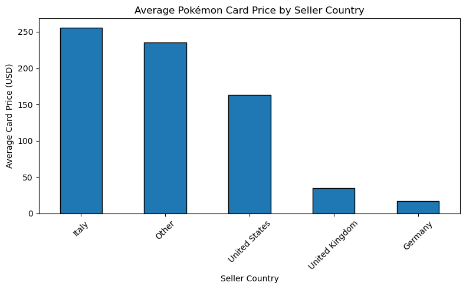

```python
country_price = (
    cards_clean
    .groupby("seller_country")["price_usd"]
    .mean()
    .sort_values(ascending=False)
    .head(10)
)

plt.figure(figsize=(8,5))

country_price.plot(
    kind="bar",
    edgecolor="black"
)

plt.title("Average Pokémon Card Price by Seller Country")
plt.xlabel("Seller Country")
plt.ylabel("Average Card Price (USD)")
plt.xticks(rotation=45)

plt.tight_layout()

plt.savefig(
    "seller_country_pricing.png",
    dpi=300,
    bbox_inches="tight"
)

plt.show()
```

### Key Findings

- Average card prices varied across seller countries.
- Italy and the United States exhibited higher average prices than several other regions.
- Differences may reflect market size, collector demand, card availability, or grading practices across international marketplaces.

# Final Cleaned Dataset Preview

```python
print("Final merged dataset shape:", merged_df.shape)

merged_df.head(10)
```

```
Final merged dataset shape: (60, 9)
```

|  | name | pokemon_type | total | height_m | weight_kg | base_experience | rarity_class | price_usd | condition_std |
| --- | --- | --- | --- | --- | --- | --- | --- | --- | --- |
| 0 | Bulbasaur | Grass Poison | 318 | 0.7 | 6.9 | 64 | Common | 17.09 | Near Mint |
| 1 | Bulbasaur | Grass Poison | 318 | 0.7 | 6.9 | 64 | Unknown | 27.93 | Near Mint |
| 2 | Ivysaur | Grass Poison | 405 | 1.0 | 13.0 | 142 | AR | 62.57 | ACE 10 |
| 3 | Ivysaur | Grass Poison | 405 | 1.0 | 13.0 | 142 | AR | 5.50 | Near Mint |
| 4 | Ivysaur | Grass Poison | 405 | 1.0 | 13.0 | 142 | Unknown | 42.31 | ACE 9 |
| 5 | Venusaur | Grass Poison | 525 | 2.0 | 100.0 | 236 | RR | 1.99 | Near Mint |
| 6 | Venusaur | Grass Poison | 525 | 2.0 | 100.0 | 236 | Rare | 152.12 | Near Mint |
| 7 | Venusaur | Grass Poison | 525 | 2.0 | 100.0 | 236 | Rare Holo | 72.38 | Near Mint |
| 8 | Venusaur | Grass Poison | 525 | 2.0 | 100.0 | 236 | Unknown | 9.45 | Near Mint |
| 9 | Venusaur | Grass Poison | 525 | 2.0 | 100.0 | 236 | Unknown | 141.31 | PSA 10 |

### Dataset Notes

- Multiple records may exist for the same Pokémon due to differences in rarity classifications, grading conditions, and marketplace listings.
- This reflects real-world marketplace variability and allows comparison of how card characteristics influence market value.

## Final Analytical Dataset

The final merged dataset contained 60 records and 9 analytical variables derived from three independent Pokémon data sources. The integrated dataset combines Pokémon battle statistics, API-derived attributes, rarity classifications, card condition information, and marketplace pricing data.

This consolidated dataset served as the foundation for all exploratory analysis and visualizations presented in this project.

## Overall Project Findings

- Pokémon card rarity demonstrated a stronger relationship with market value than base battle statistics.
- Card condition and grading status substantially influenced marketplace pricing.
- SQL joins successfully integrated three independent datasets into a unified analytical database.
- Data cleaning and standardization were critical for maintaining consistency across sources.
- Marketplace values varied across seller regions, suggesting geographic differences in collector demand and card availability.

## Project Summary

This project integrated multiple Pokémon-related datasets into a consolidated SQLite database for exploratory analysis and visualization. The analysis combined Pokémon statistical information, PokéAPI attributes, and trading card marketplace pricing data to create a unified analytical dataset.

Several data preparation and transformation steps were performed to improve consistency and compatibility across data sources. These steps included standardizing column names, formatting Pokémon names, handling missing values, removing duplicate records, and selecting relevant analytical features. The cleaned datasets were loaded into SQLite and integrated using SQL INNER JOIN operations based on Pokémon name fields.

The resulting dataset enabled analysis of relationships between Pokémon characteristics, rarity classifications, card conditions, and marketplace pricing. Visualizations revealed that rarity and card condition appeared to have stronger associations with market value than Pokémon battle statistics alone. This project demonstrated the practical application of data cleaning, web scraping, API integration, SQL database construction, relational joins, and data visualization within a single analytical workflow.

## Ethical Considerations

The datasets used in this project were obtained from publicly accessible sources, including PokéAPI and publicly available Pokémon card marketplace data. These sources were selected because they are widely used, structured, and appropriate for educational and analytical purposes. No personally identifiable information was collected, stored, or analyzed.

Several assumptions were made during the data preparation process. Pokémon names were used as the primary merge key across datasets, assuming that records with matching names represented the same entities. However, marketplace listings may vary because of grading differences, promotional releases, special editions, or regional variations. These factors may introduce minor inconsistencies within the merged dataset.

Potential ethical concerns include inaccurate pricing interpretations resulting from incomplete marketplace data, grading subjectivity, or seller-specific pricing behavior. Data transformation and filtering decisions may also introduce bias by emphasizing certain rarity classifications or card conditions. To mitigate these risks, original pricing values were preserved whenever possible, preprocessing decisions were documented transparently, and assumptions were clearly identified throughout the project.

This project highlights the importance of ethical data preparation practices, transparency in analytical workflows, and careful interpretation of results when integrating multiple independent data sources.

## Future Improvements

Future enhancements could include expanding the card marketplace dataset, incorporating historical pricing trends, applying predictive modeling techniques to estimate card values, and developing an interactive dashboard for exploring Pokémon market behavior.